# A3: More on Graphs

### Adding a Categorical Variable

We can now add a grouping variable to the boxplot similar to what we did for histograms. The grouping variable will be added using the `y` argument in the `aes()` function in `ggplot`.

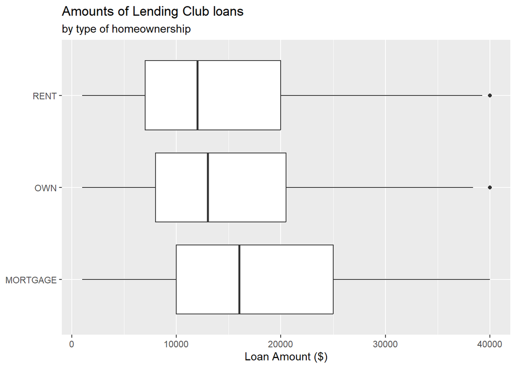

```r
ggplot(loans, aes(x = loan_amount,
                  y = homeownership)) +
  geom_boxplot() +
  labs(
    x = "Loan Amount ($)",
    y = NULL,
    title = "Amounts of Lending Club loans",
    subtitle = "by type of homeownership"
  )
```

If we want to color the boxplot with a different color for each type of `homeownership`, we use the `fill` argument in the `aes()` function in `ggplot`.

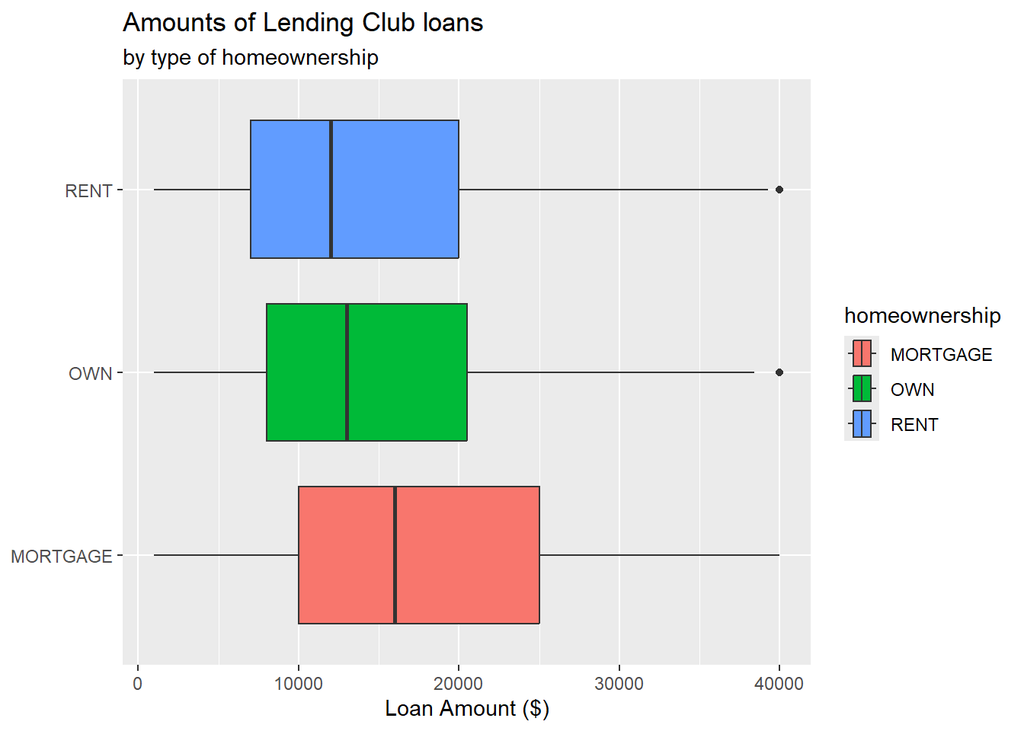

```r
ggplot(loans, aes(x = loan_amount,
                  y = homeownership, fill=homeownership)) +
  geom_boxplot() +
  labs(
    x = "Loan Amount ($)",
    y = NULL,
    title = "Amounts of Lending Club loans",
    subtitle = "by type of homeownership"
  )
```

**Action:**

Using the loans dataframe, create boxplots of `interest_rate` sepearted by `grade`, coloring each box a different color based on `grade`. Use appropriate labels and titles. Put your code in the appropriate location (see image below) in your R Markdown template (`.Rmd` file).

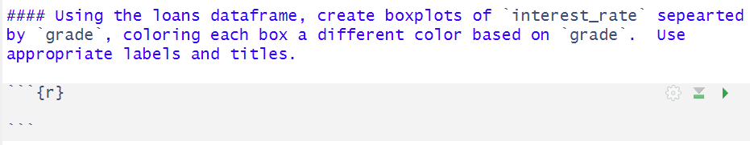

## Scatterplot

We have seen previously seen how to look at the relationship between 2 numerical variables using a scatterplot.

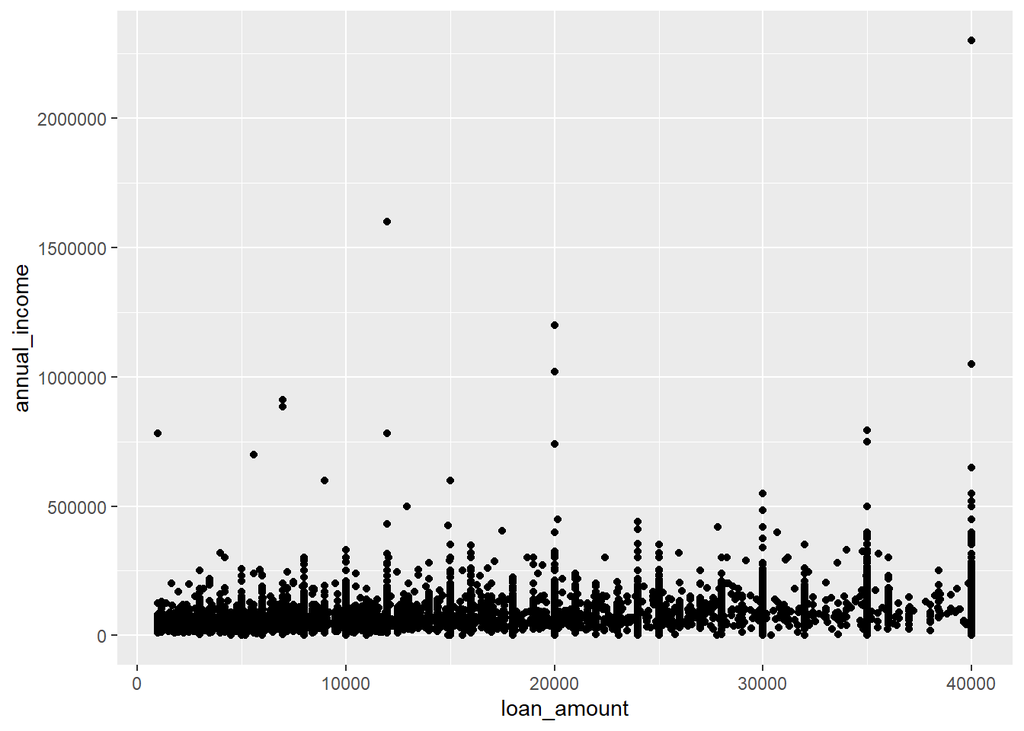

```r
ggplot(loans, aes(x = loan_amount, y = annual_income)) +
  geom_point()
```

### Custimizing Scatterplots

#### Adding Labels

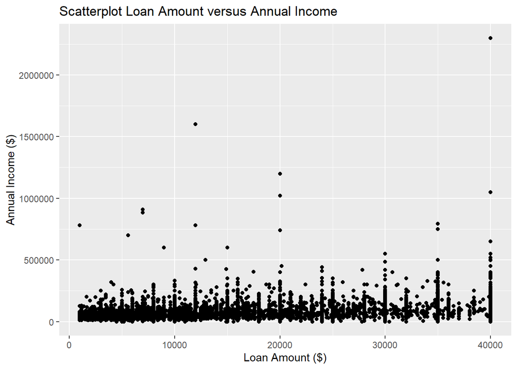

```r
ggplot(loans, aes(x = loan_amount, y = annual_income)) +
  geom_point()  +
  labs(
    x = "Loan Amount ($)",
    y = "Annual Income ($)",
    title = "Scatterplot Loan Amount versus Annual Income"
  )
```

#### Changing Point Color

You can change the color of the points in a scatterplot by adding `color` argument to the `geom_point()` function.

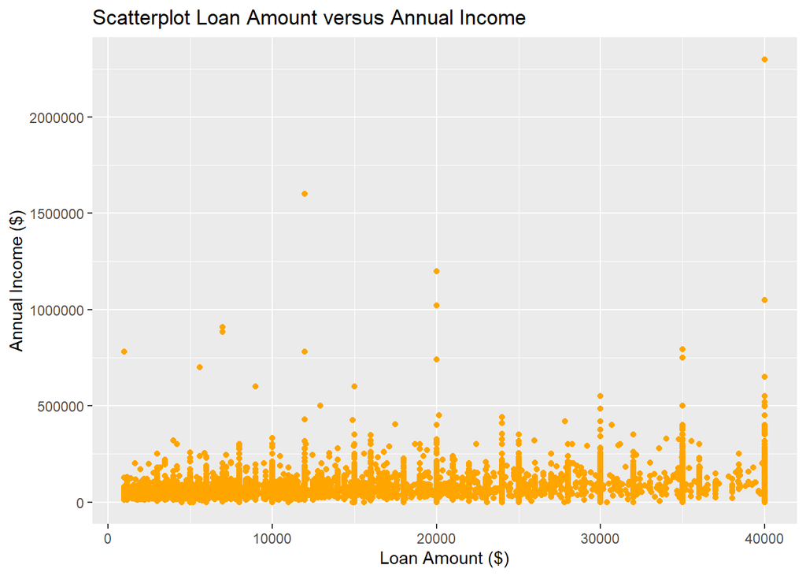

```r
ggplot(loans, aes(x = loan_amount, y = annual_income)) +
  geom_point(color="orange") +
   labs(
    x = "Loan Amount ($)",
    y = "Annual Income ($)",
    title = "Scatterplot Loan Amount versus Annual Income"
  )
```

#### Changing Point Size

You can change the point size with the argument `size` in the `geom_point()` function.

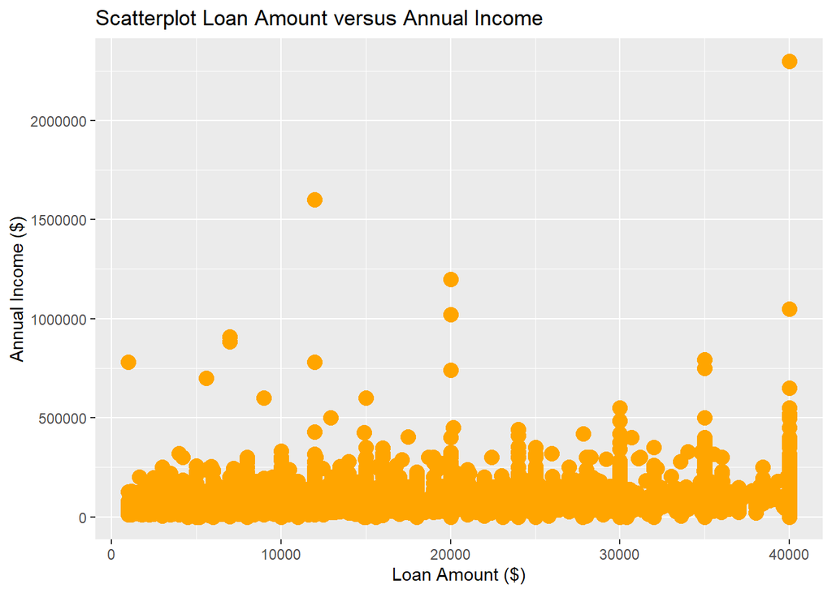

```r
ggplot(loans, aes(x = loan_amount, y = annual_income)) +
  geom_point(color="orange", size=4) +
   labs(
    x = "Loan Amount ($)",
    y = "Annual Income ($)",
    title = "Scatterplot Loan Amount versus Annual Income"
  )
```

#### Changing Point Type

You can change the type or shape of the points by designatinge `shape` corresponding to the following table.

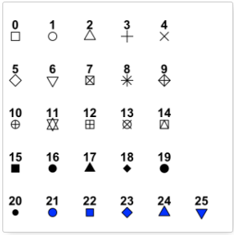

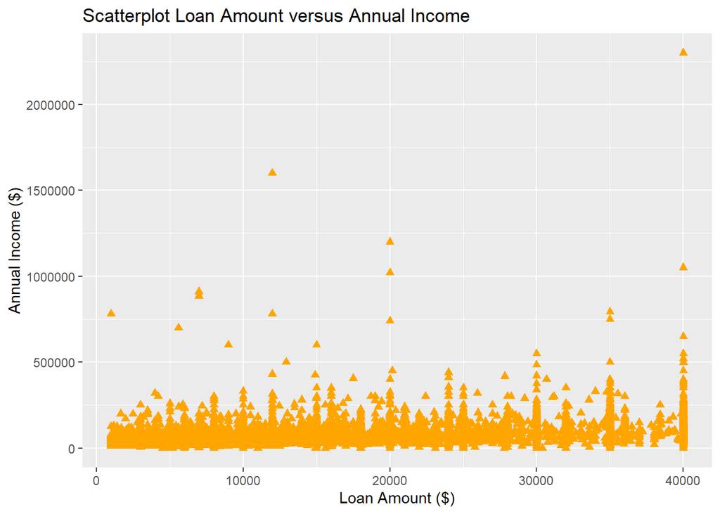

```r
ggplot(loans, aes(x = loan_amount, y = annual_income)) +
  geom_point(color="orange",
             size=2,
             shape = 17) +
   labs(
    x = "Loan Amount ($)",
    y = "Annual Income ($)",
    title = "Scatterplot Loan Amount versus Annual Income"
  )
```

### Adding in Categorical Variable

We have already seen how you can add coloring for a categorical variable by adding color equal to a categorical variable to the aesthetics.

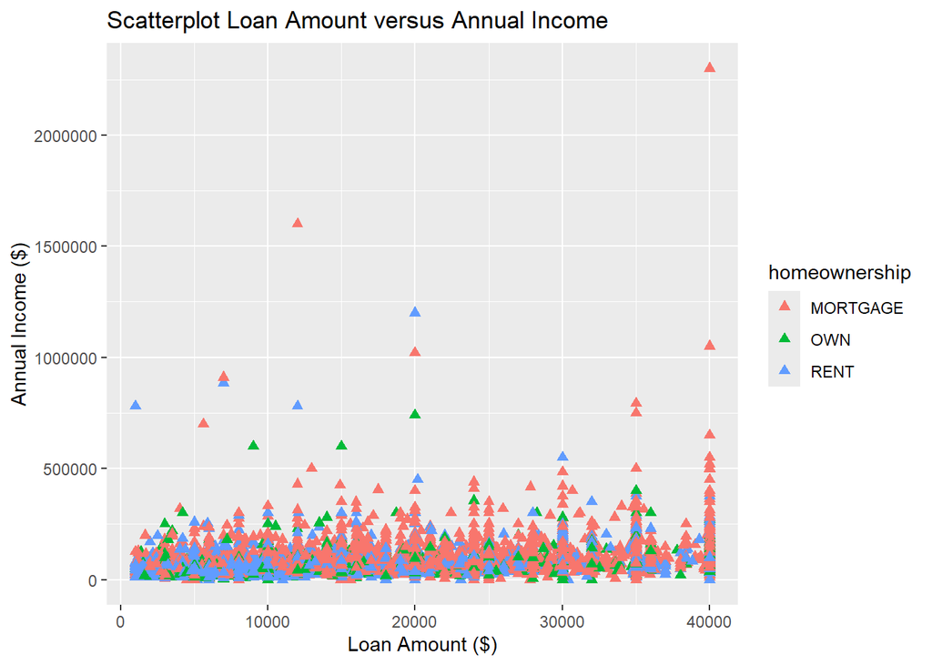

```r
ggplot(loans, aes(x = loan_amount, y = annual_income, color=homeownership)) +
  geom_point(size=2,
             shape = 17) +
   labs(
    x = "Loan Amount ($)",
    y = "Annual Income ($)",
    title = "Scatterplot Loan Amount versus Annual Income"
  )
```

You can also change the size of the point for each value of a categorical variable…

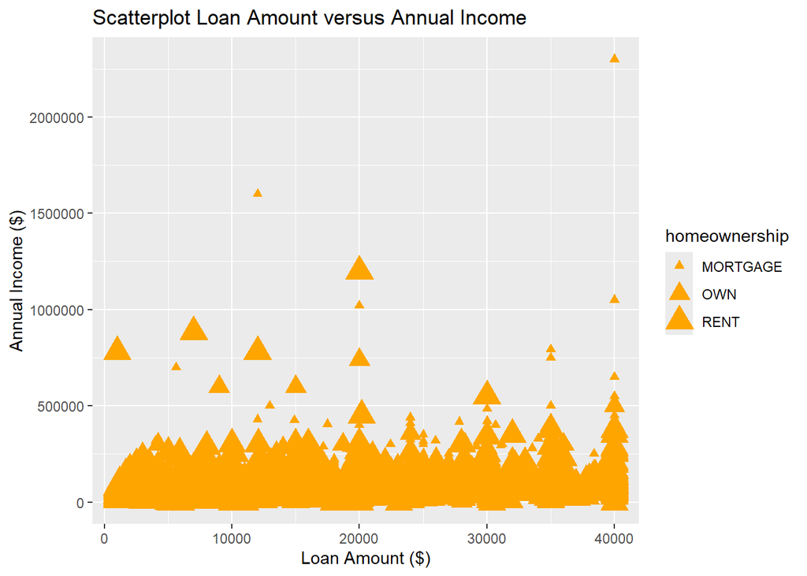

```r
ggplot(loans, aes(x = loan_amount, y = annual_income, size=homeownership)) +
  geom_point(color="orange",
             shape = 17) +
   labs(
    x = "Loan Amount ($)",
    y = "Annual Income ($)",
    title = "Scatterplot Loan Amount versus Annual Income"
  )
```

Or the type…

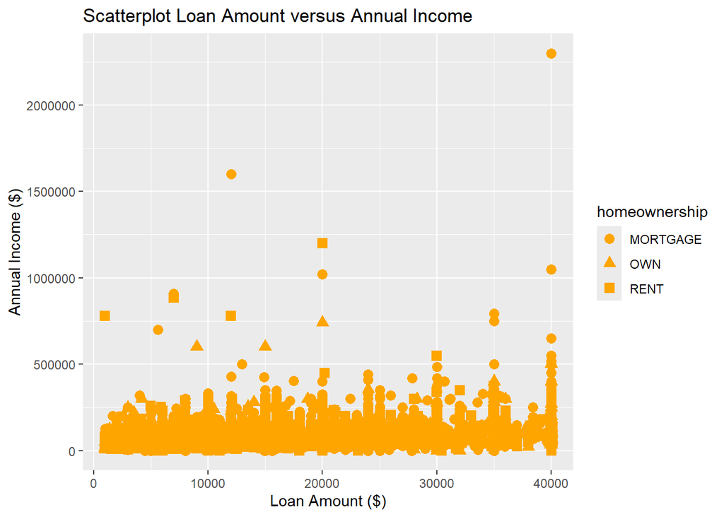

```r
ggplot(loans, aes(x = loan_amount, y = annual_income, shape = homeownership)) +
  geom_point(color="orange",
             size = 3) +
   labs(
    x = "Loan Amount ($)",
    y = "Annual Income ($)",
    title = "Scatterplot Loan Amount versus Annual Income"
  )
```

## Hexplot

Another way to look at this relationship is with hexplots. Hexplots are 2D plots in which bins are diplayed in hexagons and the color represents the number of data points within each bin.

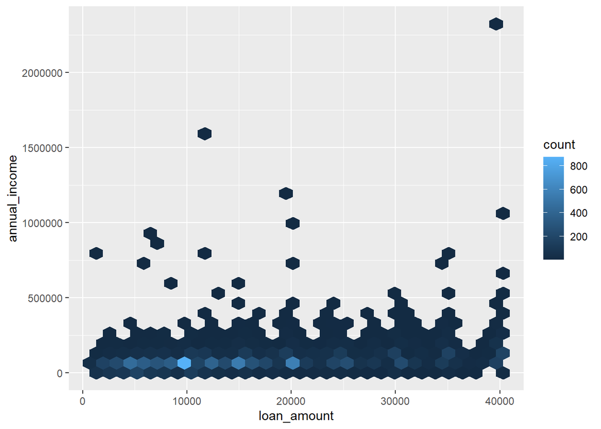

```r
ggplot(loans, aes(x = loan_amount, y = annual_income)) +
  geom_hex()
```

**Note:**

You may need to install the package `hexbin` R Studio for the hexplot to work. You will also need to load the `hexbin` in you R Markdown file (there is a spot to do this at the top of the template that says “Load packages needed” but you can put it anywhere.)

### Customizing Hexplot

You can change the discrete color of the hexplot by using `color` and `fill`.

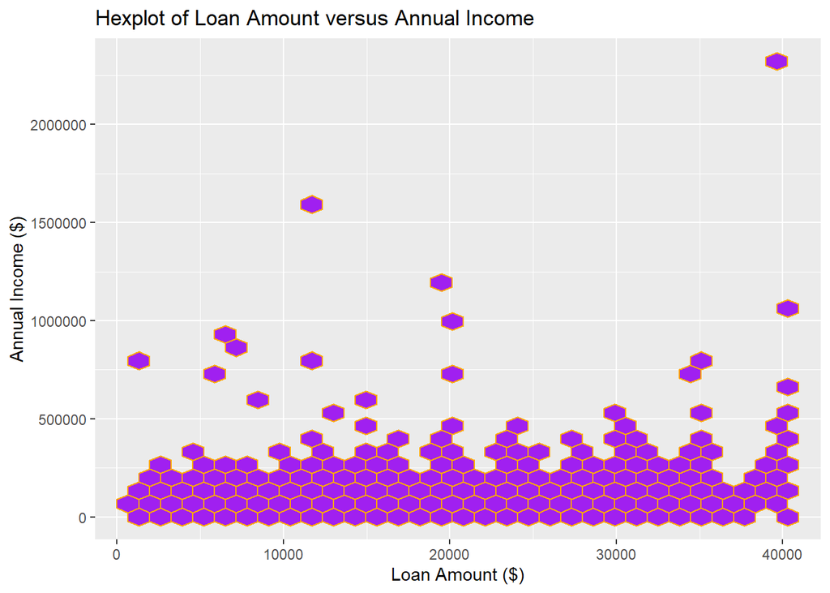

```r
ggplot(loans, aes(x = loan_amount, y = annual_income)) +
  geom_hex(color="orange", fill="purple") +
  labs(
    x = "Loan Amount ($)",
    y = "Annual Income ($)",
    title = "Hexplot of Loan Amount versus Annual Income"
  )
```

However, if you want to keep the gradient nature but change the color pallete you can use some of the `scale_fill_XXX` functions. Below we have used `scale_fill_viridis_c` Changing the color of a hexplot while keeping the gradient

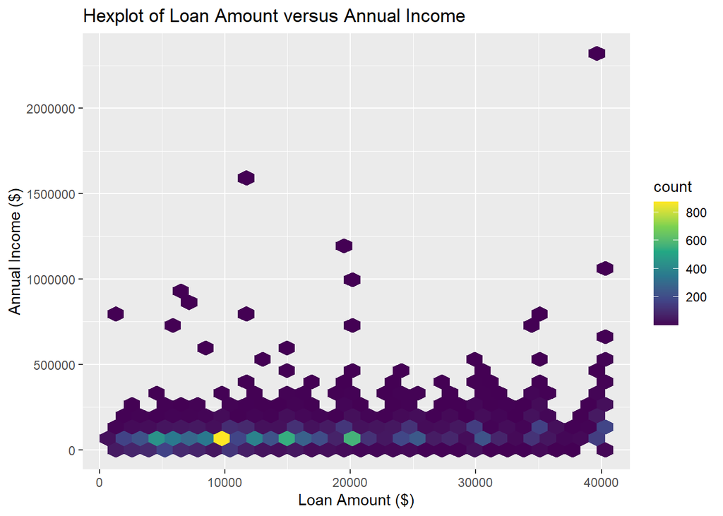

```r
ggplot(loans, aes(x = loan_amount, y = annual_income)) +
  geom_hex() +
  labs(
    x = "Loan Amount ($)",
    y = "Annual Income ($)",
    title = "Hexplot of Loan Amount versus Annual Income"
  ) +
  scale_fill_viridis_c()
```

**Action:**

Using the loans dataframe create a hexplot of `loan_amount` vs. `interest_rate` colored by `grade` (Hint: use the `fill` argument). Please provide appropriate title(s) and labels. Put your code in the appropriate location (see image below) in your R Markdown template (`.Rmd` file).

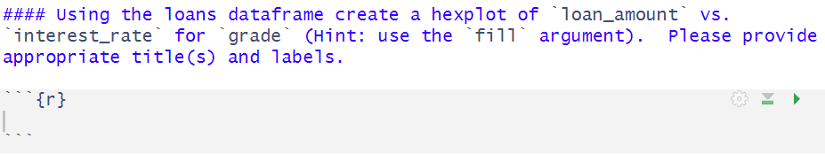

## Use Wrangling Tools to limit data

You may use the transformation or wrangling tools (filter, select, etc.) within (or outside of) ggplot to create a graph of a subset or the data.

### Example using Hexplot

For example, you can create a hexplot for just `annual_income` values less than 500000. Typically the use of wrangling tools within the ggplot function are used in the first argument (where the dataset goes).

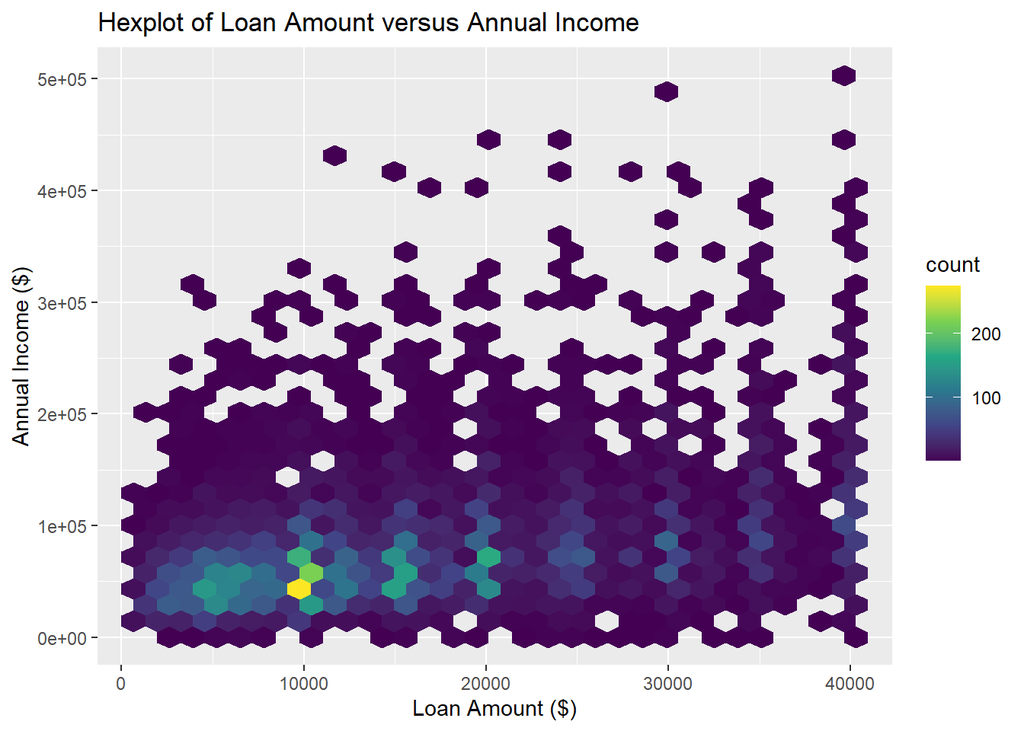

```r
ggplot(loans %>% filter(annual_income < 500000),
       aes(x = loan_amount, y = annual_income)) +
  geom_hex() +
  labs(
    x = "Loan Amount ($)",
    y = "Annual Income ($)",
    title = "Hexplot of Loan Amount versus Annual Income"
  ) +
  scale_fill_viridis_c()
```

**Action:**

Using the loans dataframe and the idea that you can filter within the ggplot function, create a hexplot of `loan_amount` vs. `interest_rate` colored by `grade` values A thru F (exclude grade G). Please provide appropriate title(s) and labels.

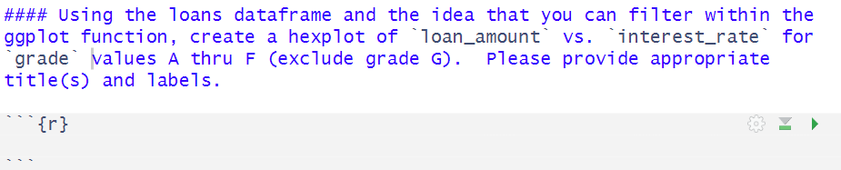

## Violin Plot

A violin plot is a method of plotting numeric data. It is similar to a box plot, with the addition of a rotated kernel density plot on each side. <sup>4</sup>

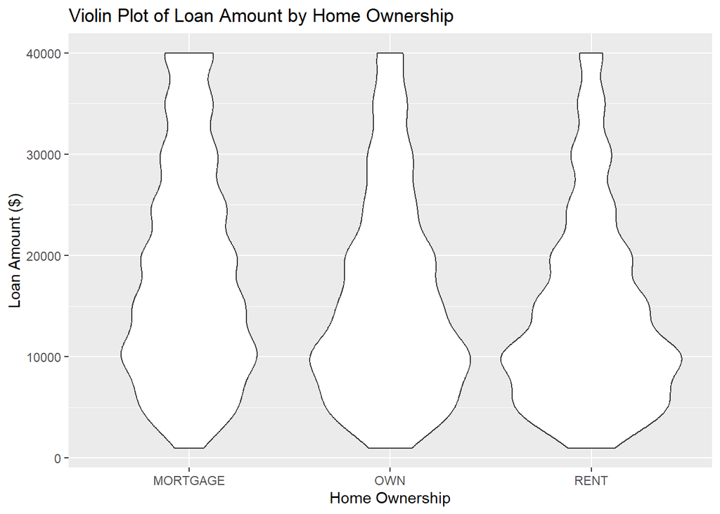

```r
ggplot(loans, aes(x = homeownership, y = loan_amount)) +
  geom_violin() +
  labs(x = "Home Ownership",
       y = "Loan Amount ($)",
       title = "Violin Plot of Loan Amount by Home Ownership")
```

We can fill each plot with color for each type of homeownship using a method similar to what we did with boxplots.

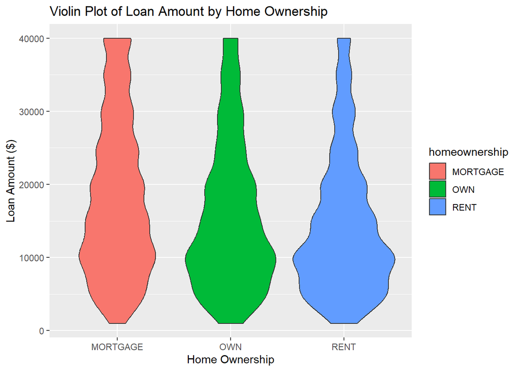

```r
ggplot(loans, aes(x = homeownership, y = loan_amount, fill=homeownership)) +
  geom_violin() +
    labs(x = "Home Ownership",
       y = "Loan Amount ($)",
       title = "Violin Plot of Loan Amount by Home Ownership")
```

## Ridge Plot

A Ridgeline plot (sometimes called Joyplot) shows the distribution of a numeric value for several groups. Distribution can be represented using histograms or density plots, all aligned to the same horizontal scale and presented with a slight overlap.<sup>2</sup>

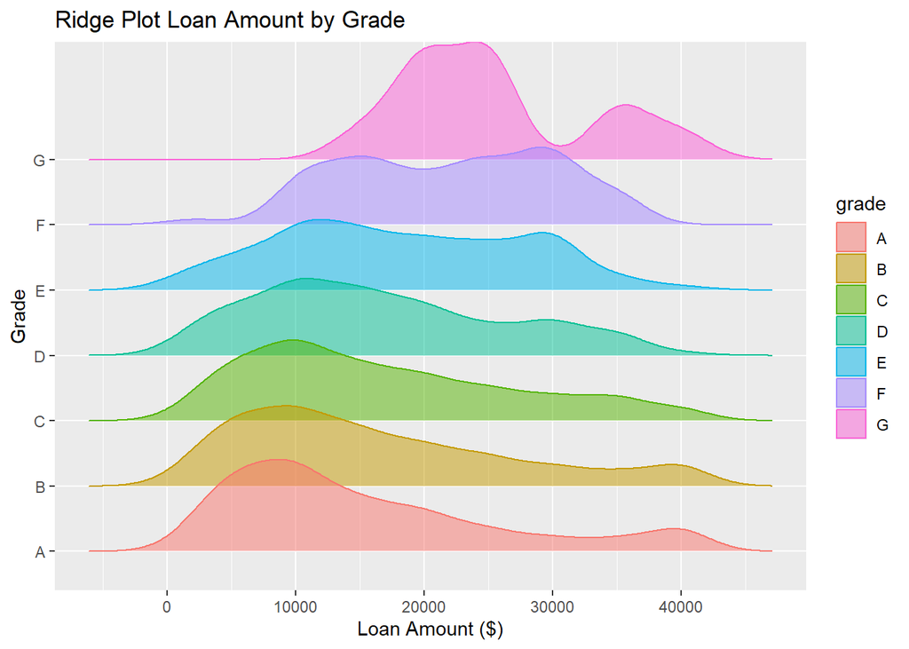

```r
library(ggridges)
ggplot(loans, aes(x = loan_amount,
                  y = grade,
                  fill = grade,
                  color = grade)) +
  geom_density_ridges(alpha = 0.5) +
    labs(x = "Loan Amount ($)",
       y = "Grade",
       title = "Ridge Plot Loan Amount by Grade")
```

# Visualizing Categorical Data

## Bar chart

A standard way to visually display one categorical (or factor) variable is with a bar chart. A basic bar chart of homeownership is given below.

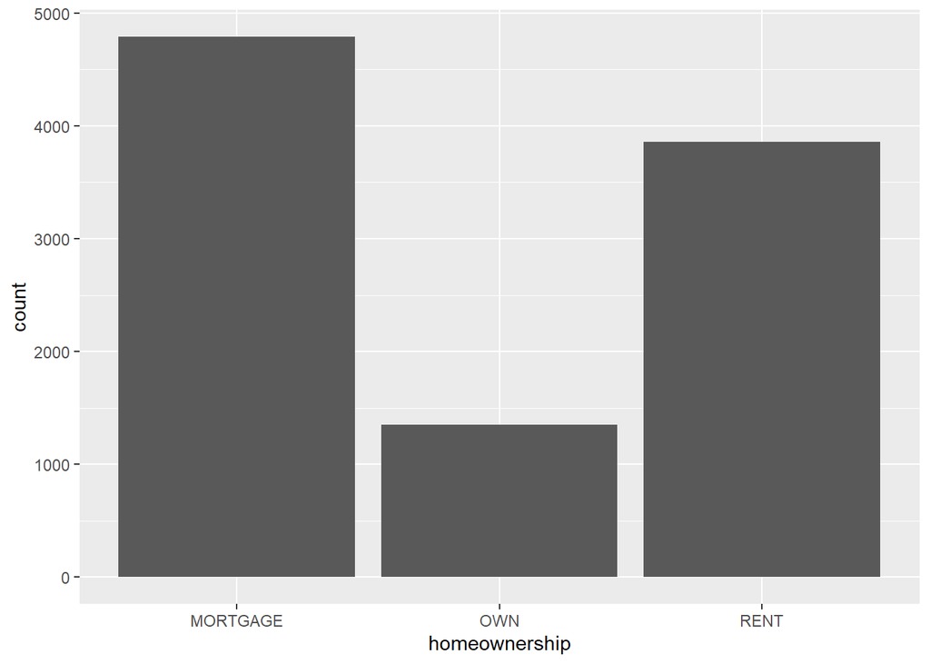

```r
ggplot(loans, aes(x = homeownership)) +
  geom_bar()
```

### Customizing Bar Chart

Adding titles, colors, and labels to the bar chart.

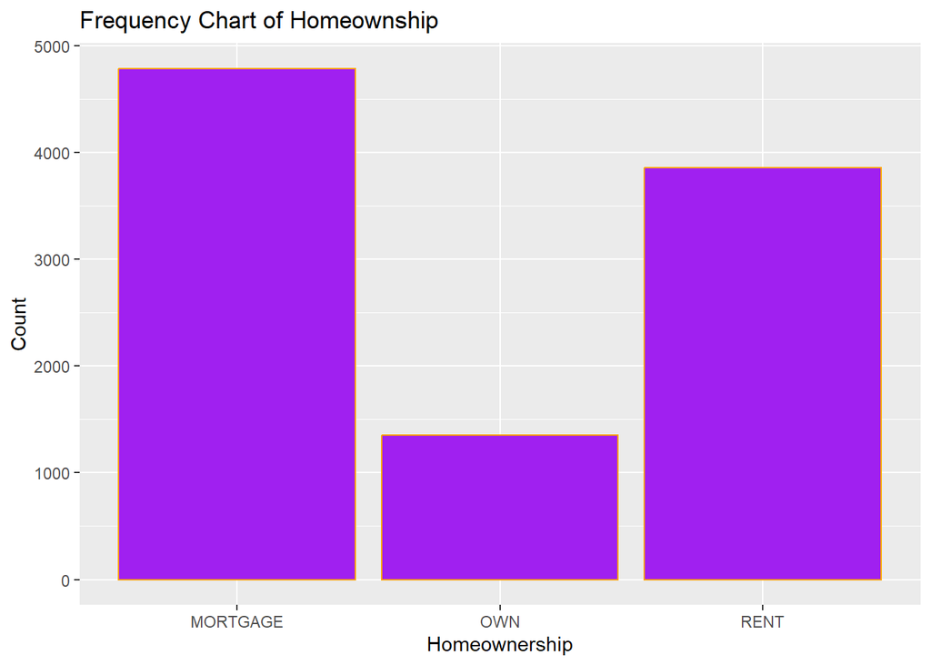

```r
ggplot(loans, aes(x = homeownership)) +
  geom_bar(color="orange", fill="purple") +
  labs(
    x="Homeownership",
    y= "Count",
    title= "Frequency Chart of Homeownship"
  )
```

You can add frequency labels to the bar charts using `geom_text()`. I won’t get into all the details of the function here but just so you know this is available.

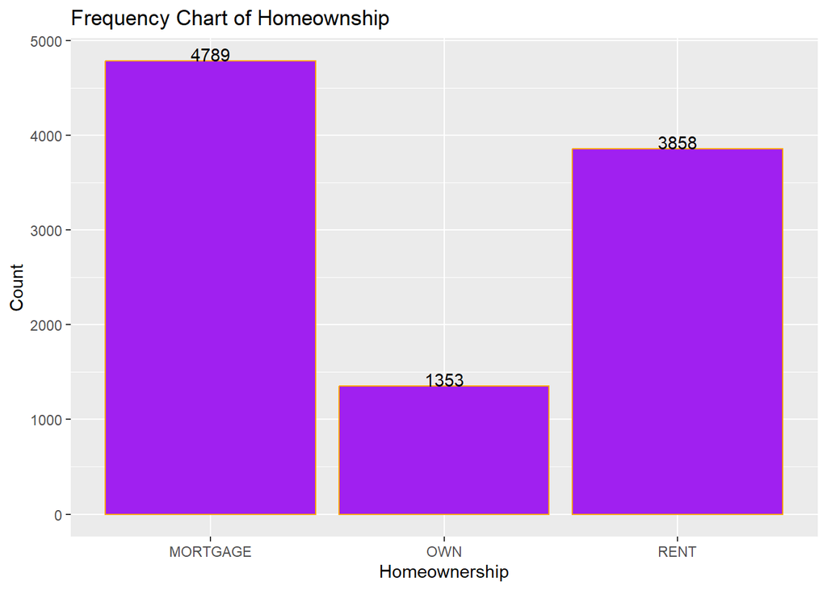

```r
ggplot(loans, aes(x = homeownership)) +
  geom_bar(color="orange", fill="purple") +
  geom_text(stat = "count",
            aes(label = after_stat(count)),
            vjust = 0) +
  labs(
    x="Homeownership",
    y= "Count",
    title= "Frequency Chart of Homeownship"
  )
```

You can also change the orientation of the graph by making the variable of interest the `y` variable rather than the `x` variable.

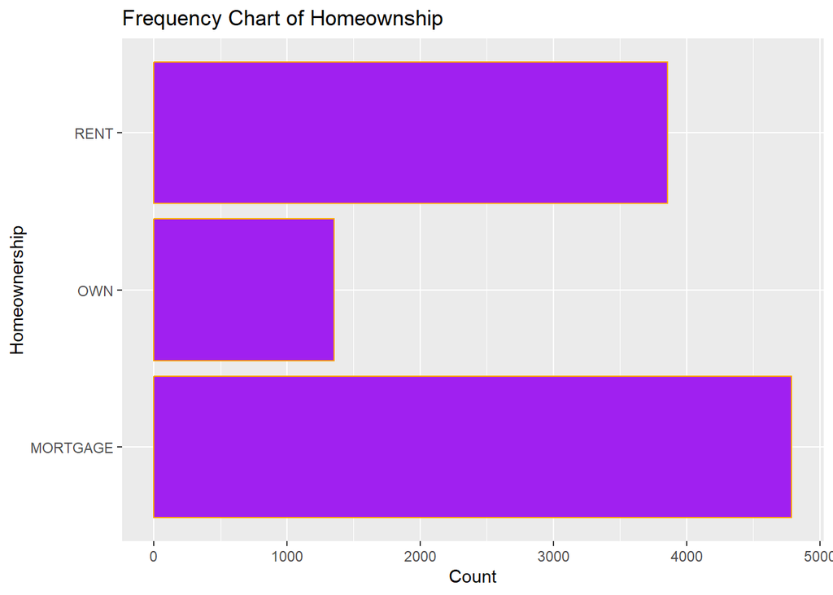

```r
ggplot(loans, aes(y = homeownership)) +
  geom_bar(color="orange", fill="purple") +
  labs(
    x="Count",
    y= "Homeownership",
    title= "Frequency Chart of Homeownship"
  )
```

You can change the y axis to be proportion rather than frequency using the `after_stat` function in the aesthetics and the `group=1` argument.

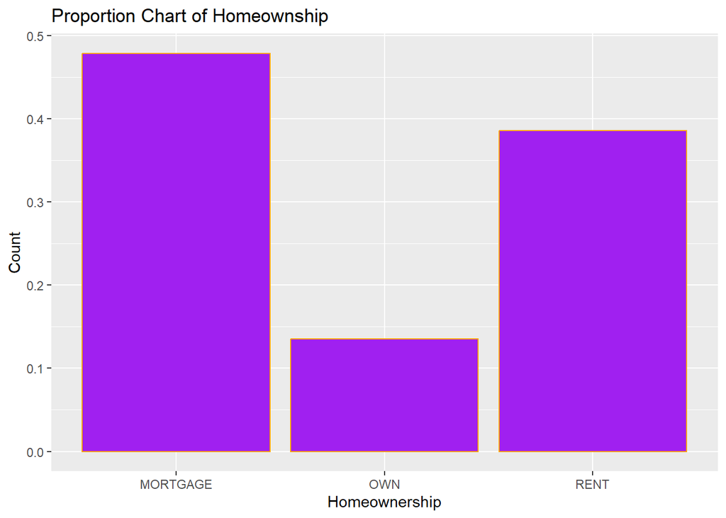

```r
ggplot(loans, aes(x = homeownership, y=after_stat(prop), group=1)) +
  geom_bar(color="orange", fill="purple") +
  labs(
    x="Homeownership",
    y= "Count",
    title= "Proportion Chart of Homeownship"
  )
```

### Adding a Categorical Variable

You can add coloring for an additional categorical variable by using the `fill` argument. If you add the `position = "dodge"` code to the `geom_bar()` function this will give you a side-by-side bar graph.

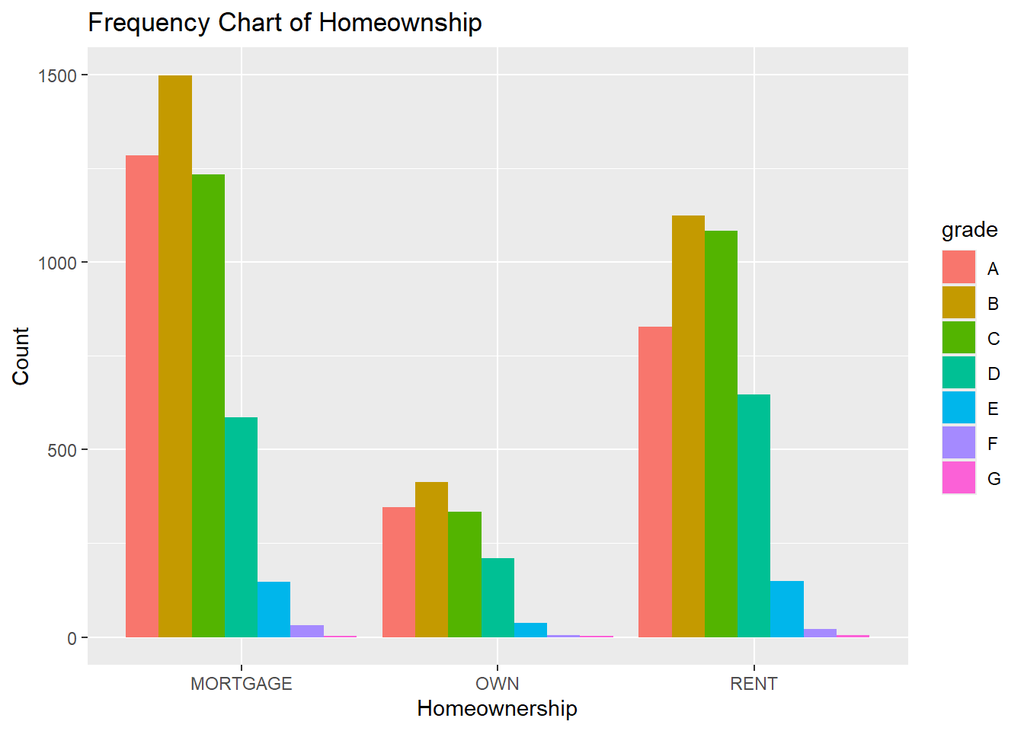

```r
ggplot(loans, aes(x = homeownership, fill=grade)) +
  geom_bar(position = "dodge") +
  labs(
    x="Homeownership",
    y= "Count",
    title= "Frequency Chart of Homeownship"
  )
```

### Segmented Bar Chart

A segmented bar chart provides a visual display of a categorical variable broken down by another categorical variable. There are two ways to represent a segmented bar chart. The difference has to do with what the height of the bars represents.

For the following bar chart the height of the vertical bars represents the count of each type of homeownership.

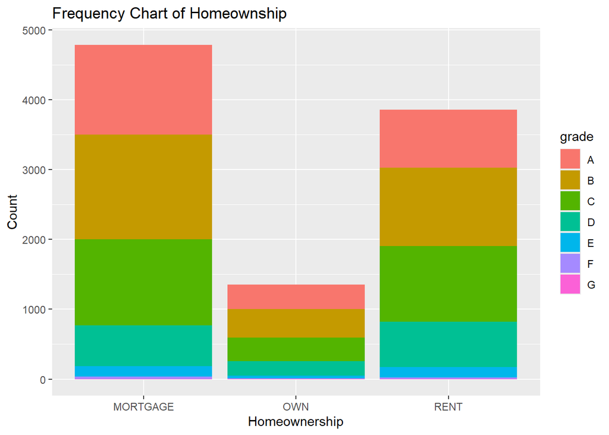

```r
ggplot(loans, aes(x = homeownership,
                  fill = grade)) +
  geom_bar() +
    labs(
    x="Homeownership",
    y= "Count",
    title= "Frequency Chart of Homeownship"
  )
```

OR

For the next bar chart (adding `position=“fill” to the geom_bar function) the height of the vertical bars represents the percentage per each homeownership broken down by grade. Notice each bar represents 100% of each type of homeownership.

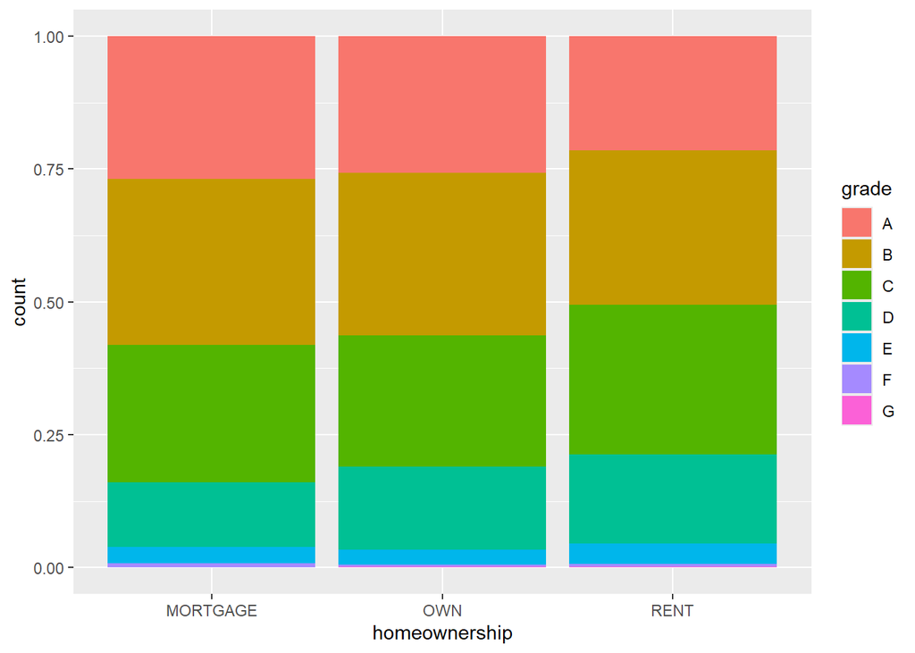

```r
ggplot(loans, aes(x = homeownership, fill = grade)) +
  geom_bar(position = "fill")
```

Think about which bar plot is a more useful representation for visualizing the relationship between homeownership and grade?

**Action:**

Using the `loans` dataframe, create a segmented bar chart of `state` segmented by `homeownership`. The bars should be horizontal (not vertical) and the length of the bars should be the count for each state. The graph should have appropriate titles, and labels. Put your code in the appropriate location (see image below) in your R Markdown template (`.Rmd` file).

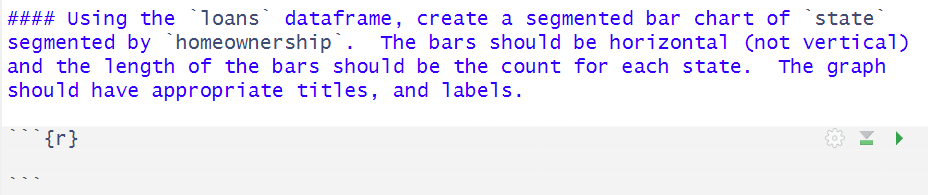

## Highlighting specifics in graphs

There is a package called `gghighlight` that can help you hightlight a particular line, group, etc. in a graph. Below are some brief examples using this package. You can find out more [here](https://cran.r-project.org/web/packages/gghighlight/vignettes/gghighlight.html).

### Histogram

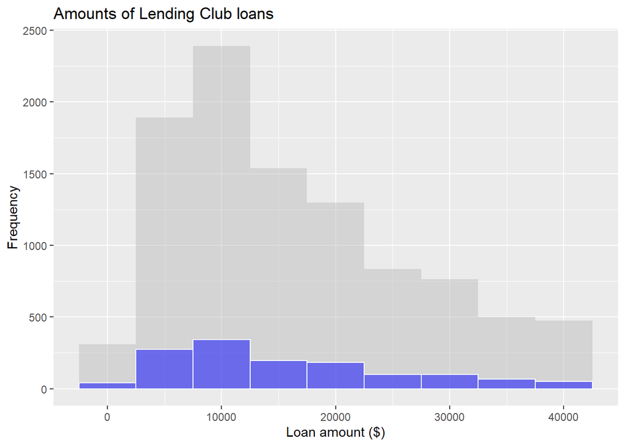

```r
ggplot(loans, aes(x = loan_amount)) +
  geom_histogram(binwidth = 5000, alpha=0.5, color="white", fill="blue") +
  labs(
    x = "Loan amount ($)",
    y = "Frequency",
    title = "Amounts of Lending Club loans"
  ) +
  gghighlight::gghighlight(homeownership=="OWN")
```

### Boxplot

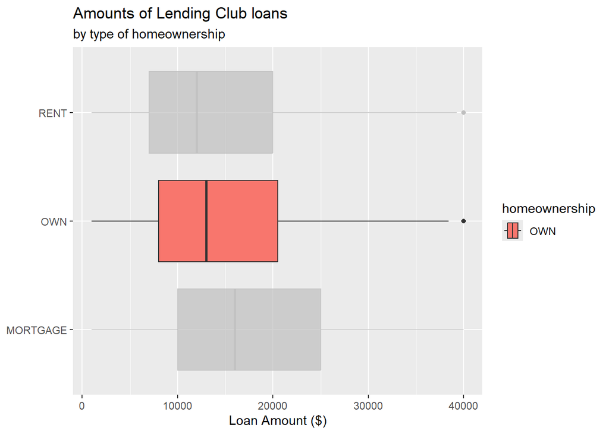

```r
ggplot(loans, aes(x = loan_amount,
                  y = homeownership, fill=homeownership)) +
  geom_boxplot() +
  labs(
    x = "Loan Amount ($)",
    y = NULL,
    title = "Amounts of Lending Club loans",
    subtitle = "by type of homeownership"
  ) +
  gghighlight::gghighlight(homeownership=="OWN")
```

### Scatterplot

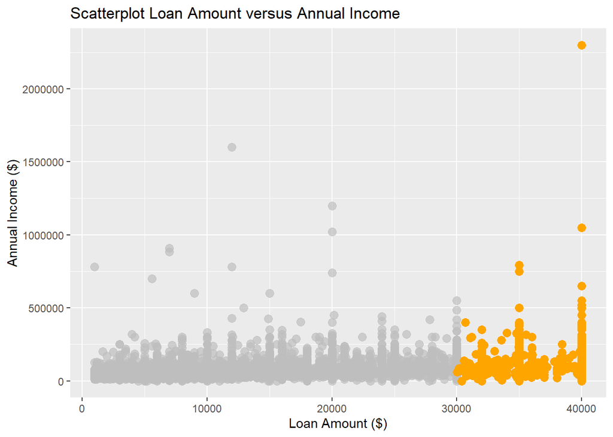

```r
ggplot(loans, aes(x = loan_amount,
                  y = annual_income)) +
  geom_point(color="orange",
             size = 3) +
   labs(
    x = "Loan Amount ($)",
    y = "Annual Income ($)",
    title = "Scatterplot Loan Amount versus Annual Income"
  ) +
  gghighlight::gghighlight(loan_amount >30000)
```

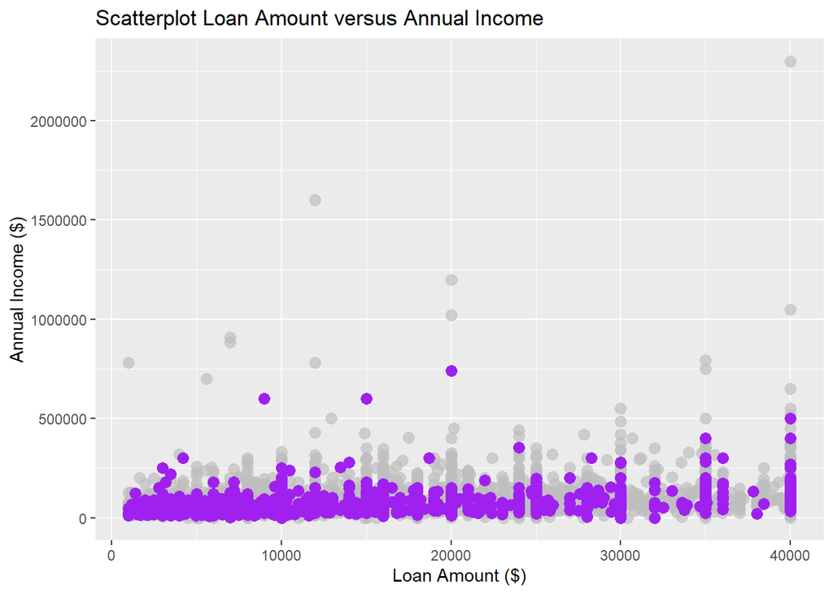

```r
ggplot(loans, aes(x = loan_amount,
                  y = annual_income)) +
  geom_point(color="purple",
             size = 3) +
   labs(
    x = "Loan Amount ($)",
    y = "Annual Income ($)",
    title = "Scatterplot Loan Amount versus Annual Income"
  ) +
  gghighlight::gghighlight(homeownership=="OWN")
```

### Bar Chart

```
## label_key: homeownership
```

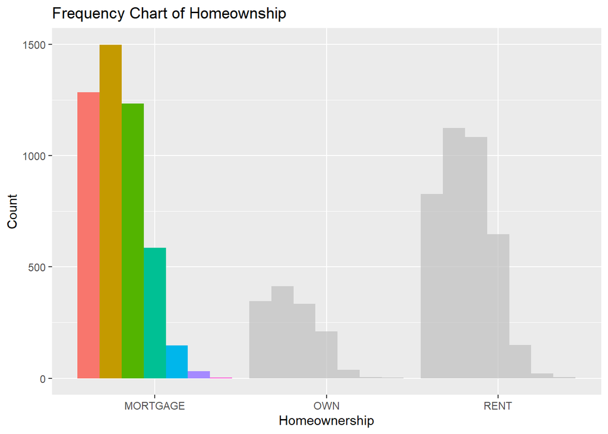

```r
ggplot(loans, aes(x = homeownership, fill=grade)) +
  geom_bar(position = "dodge") +
  labs(
    x="Homeownership",
    y= "Count",
    title= "Frequency Chart of Homeownship"
  ) +
  gghighlight::gghighlight(homeownership=="MORTGAGE")
```

Once you have completed all of your actions in your R Markdown template, be sure to “knit” the .Rmd file. When you knit you will see an .html file appear in your project folder.

**Please submit your .html file to Canvas**

# References

1. [Data Science in a Box](https://datasciencebox.org/exploring-data.html)
2. [From Data to Viz](https://www.data-to-viz.com/)
3. [towards Data Science - Understanding Boxplots](https://towardsdatascience.com/understanding-boxplots-5e2df7bcbd51)
4. [Wikipedia - Violin Plot](https://en.wikipedia.org/wiki/Violin_plot)